# A meta-analysis of genus-metabolite associations

## Get genus-metabolite associations per dataset, controlling for study group

To assess the genus-metabolite association, independently of disease state, we train linear models where the “study group” variable is added as a term to the formula.

### Organize data

We first create a “thin” table with the relevant data from each dataset.  
We apply a log-transformation (with pseudo count 1) to metabolomic data and an arcsine square root transformation to taxa relative abundances, as often applied to such data before fitting linear regressions (for example in https://www.nature.com/articles/s41586-019-1237-9).

```r
# Metadata fields to include (if exist)
metadata.fields <- c("Sample",
                     "Age",
                     "Gender",
                     "Subject",
                     "Study.Group",
                     "BMI")

data.for.lm <- lapply(datasets, function(d) {
  log_info(sprintf("Preparing data for %s", d))

  # For compactness we fetch only relevant genera and metabolites,
  #  included in our pairs of interest.

  # Get relevant genera
  relevant.genera <- common.pairs %>%
    filter(Dataset == d) %>%
    pull(Taxon) %>%
    unique()
  relevant.genera <- genera[[d]] %>%
    select("Sample", any_of(relevant.genera))

  # Arcsine square root relative abundance values
  relevant.genera[-1] <- asin(sqrt(relevant.genera[-1]))

  # Get relevant metabolites
  relevant.cmpd <- common.pairs %>%
    filter(Dataset == d) %>%
    pull(Orig.Compound) %>%
    unique()
  relevant.cmpd <- mtb[[d]] %>%
    select("Sample", any_of(relevant.cmpd))

  # Log scale metabolomics (unless already scaled)
  if (min(relevant.cmpd %>%
            summarise(across(-1, min, na.rm = T)),
          na.rm = T) >= 0)
    relevant.cmpd[-1] <- log1p(relevant.cmpd[-1])

  # Combine all variables in one table
  tmp <- metadata[[d]] %>%
    select(any_of(metadata.fields)) %>%
    mutate(Sample = as.character(Sample)) %>%
    left_join(relevant.cmpd, by = "Sample") %>%
    left_join(relevant.genera, by = "Sample")

  return(tmp)
})
names(data.for.lm) <- datasets
```

### Fit linear models

Fit a linear regression model (LM) for each genus-metabolite pair, using the following formula:  
`Compound ~ (Intercept) + Taxon [+ Study.Group]`

We also fit a second LM adjusting for additional covariates, when available:  
`Compound ~ (Intercept) + Taxon [+ Study.Group] [+ Age] [+ Gender] [+ BMI]`

Per LM we record the following statistics:

- Adjusted R^2 (can be interpreted as the % of variation in metabolite levels explained by genus abundance and other factors controlled for)
- Overall model P value (based on the F-statistic)
- Model coefficient for genus abundance (if positive, an increase in genus abundance is associated with an increase in metabolite levels, and vice versa)
- Model coefficient P value

Finally we apply an FDR correction to all P values in a specific dataset.

To enable a proper synthesize of results across multiple studies in downstream analysis, we also compute the r_sp (semi-partial correlation) as described in **Formula 2** in [Aloe, Ariel M., and Betsy Jane Becker. “An effect size for regression predictors in meta-analysis.” Journal of Educational and Behavioral Statistics 37.2 (2012): 278-297.](https://journals.sagepub.com/doi/full/10.3102/1076998610396901)

```r
if (file.exists(file.lm.results.raw)) {
  lm.results <- read_delim(file.lm.results.raw,
                           delim = "\t",
                           show_col_types = FALSE,
                           escape_double = FALSE,
                           trim_ws = TRUE)
} else {
  # Iterate over datasets (in parallel - future_lapply)
  lm.results <- future_lapply(datasets, function(d) {
    # Example: d = datasets[10]
    print(sprintf("Fitting LM models for genus-metabolite pairs in dataset: %s", d))

    # Get dataset data and list of pairs to check
    tmp <- data.for.lm[[d]]
    pairs.to.check <- common.pairs %>%
      filter(Dataset == d)

    # For each pair - fit a linear model and record results
    # Example: r = unlist(pairs.to.check[11634,])
    lms <- data.frame(
      t(apply(pairs.to.check, MARGIN = 1, function(r) {

        metab.in.pair <- unname(r["Orig.Compound"])
        genus.in.pair <- unname(r["Taxon"])
        tmp.data.for.lm <- tmp %>%
          select(all_of(c(metab.in.pair, genus.in.pair)),
                 any_of(metadata.fields)) %>%
          rename("Compound" = 1, "Taxon" = 2) %>%
          select(where(~sum(!is.na(.x)) > 0))

        # Generate the regression formula,
        #  add study.group covariate if available
        lm.formula <- as.formula("Compound ~ Taxon")
        if ("Study.Group" %in% names(tmp.data.for.lm))
          lm.formula <- add.var.to.formula(lm.formula, "Study.Group")

        # Fit the model
        lm.model <- lm(lm.formula, data = tmp.data.for.lm)
        lm.model.sum <- summary(lm.model)

        # Get the semi-partial correlation between genus
        #  abundance and metabolite using Equation 2 from
        #  Aloe and Becker, 2012 (cited above).
        r.sp <-
          (lm.model.sum$coefficients["Taxon", "t value"] *
             sqrt(1 - lm.model.sum$r.squared)) /
          (sqrt(nrow(tmp.data.for.lm) -
                  (length(lm.formula)-1) - 1))

        # Fit a second model that also controls for Age,
        #  BMI and Gender when available
        lm.formula2 <- lm.formula
        if ("Age" %in% names(tmp.data.for.lm))
          lm.formula2 <- add.var.to.formula(lm.formula2, "Age")
        if ("BMI" %in% names(tmp.data.for.lm))
          lm.formula2 <- add.var.to.formula(lm.formula2, "BMI")
        if ("Gender" %in% names(tmp.data.for.lm))
          lm.formula2 <- add.var.to.formula(lm.formula2, "Gender")
        lm.model2 <- lm(lm.formula2, data = tmp.data.for.lm)
        lm.model.sum2 <- summary(lm.model2)

        c("Dataset" = d,
          "Taxon" = genus.in.pair,
          "Orig.Compound" = metab.in.pair,
          "LM.Formula" = as.character(lm.formula),
          "LM.Adj.R2" = lm.model.sum$adj.r.squared,
          # Extract the F-statistic P value from LM model summary (goodness of fit measure)
          "LM.PVal" = unname(glance(lm.model.sum)$p.value),
          # Extract the coefficient and its P value for the taxon variable in the regression
          "LM.Taxon.Coef" = lm.model.sum$coefficients["Taxon", "Estimate"],
          "LM.Taxon.PVal" = lm.model.sum$coefficients["Taxon", "Pr(>|t|)"],
          "LM.Taxon.r.sp" = r.sp,
          "LM2.Formula" = as.character(lm.formula2),
          "LM2.Adj.R2" = lm.model.sum2$adj.r.squared,
          # Extract the F-statistic P value from LM model summary (goodness of fit measure)
          "LM2.PVal" = unname(glance(lm.model.sum2)$p.value),
          # Extract the coefficient and its P value for the taxon variable in the regression
          "LM2.Taxon.Coef" = lm.model.sum2$coefficients["Taxon", "Estimate"],
          "LM2.Taxon.PVal" = lm.model.sum2$coefficients["Taxon", "Pr(>|t|)"])
    })))

    # Sanity
    sprintf("Sanity: fitted %i/%i requested models", nrow(pairs.to.check), nrow(lms))

    # Convert numbers back to numeric
    lms <- lms %>% mutate_at(c("LM.Adj.R2","LM2.Adj.R2",
                               "LM.Taxon.PVal","LM2.Taxon.PVal",
                               "LM.Taxon.Coef","LM2.Taxon.Coef",
                               "LM.PVal","LM2.PVal","LM.Taxon.r.sp"),
                             as.numeric)

    # Apply FDR
    lms$LM.Taxon.FDR <- p.adjust(lms$LM.Taxon.PVal, method = "fdr")
    lms$LM2.Taxon.FDR <- p.adjust(lms$LM2.Taxon.PVal, method = "fdr")

    n.models <- nrow(lms)
    n.sig.models <- sum(lms$LM.Taxon.FDR < 0.05)
    sprintf("Of %i LM models, %i (%.2f%%) resulted in significant associations",
            n.models, n.sig.models, 100*n.sig.models/n.models)

    return(lms)
  }, future.packages = c("logger", "formula.tools", "broom"))

  # Merge into one big table
  lm.results <- bind_rows(lm.results)

  # Add details per pair
  lm.results <- lm.results %>%
    left_join(common.pairs, by = c("Dataset","Taxon","Orig.Compound"))

  # Per dataset, take only the best model per genus-metabolite pair
  # (for cases where a compound was measured more than once, for example when running multiple MS methods)
  lm.results <- lm.results %>%
    group_by(Dataset, Pair) %>%
    slice_min(order_by = LM.Taxon.FDR, with_ties = FALSE) %>%
    ungroup()

  write_delim(lm.results, file = file.lm.results.raw, delim = "\t")
}
```

```r
paste0("A total of ", nrow(lm.results), " linear models were fitted")
n.lm.signif <- lm.results %>% filter(LM.Taxon.FDR < 0.05) %>% nrow()
paste0(n.lm.signif, " (", round(100*n.lm.signif/nrow(lm.results),2), "%) of which had a FDR<0.05 for the genus coefficient")
```

```
## [1] "A total of 132391 linear models were fitted"
## [1] "18075 (13.65%) of which had a FDR<0.05 for the genus coefficient"
```

### Summarize results & add HMDB information

```r
if (file.exists(file.hmdb.data)) {
  hmdb.data <- read_delim(file.hmdb.data,
                          delim = "\t",
                          show_col_types = FALSE,
                          escape_double = FALSE,
                          trim_ws = TRUE)
} else {
  hmdb.ids <- unique(lm.results$Compound)
  hmdb.data <- get.hmdb.data.by.ids(hmdb.ids)
  hmdb.data <- hmdb.data %>% rename(Compound = HMDB)

  # Manually fill-in some missing KEGG's
  hmdb.data$KEGG[hmdb.data$Compound == "HMDB0000043"] <- "D07523"
  hmdb.data$KEGG[hmdb.data$Compound == "HMDB0000613"] <- "C21593"
  hmdb.data$KEGG[hmdb.data$Compound == "HMDB0004704"] <- "C14828"

  # ... and some missing classes
  hmdb.data$HMDB.Class[hmdb.data$Compound == "HMDB0000357"] <-
    "Hydroxy acids and derivatives"
  hmdb.data$HMDB.Super.Class[hmdb.data$Compound == "HMDB0000357"] <-
    "Organic acids and derivatives"
  hmdb.data$HMDB.Class[hmdb.data$Compound == "METPA0797"] <-
    "Carboxylic acids and derivatives"
  hmdb.data$HMDB.Super.Class[hmdb.data$Compound == "METPA0797"] <-
    "Amino acids, peptides, and analogues"

  write_delim(hmdb.data, file = file.hmdb.data, delim = "\t")
}
```

Show agreement/disagreement between datasets for a sample of metabolites and microbes:

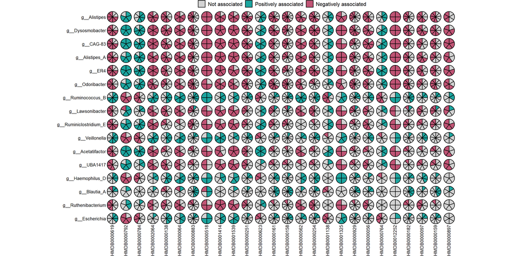

```r
not.assoc.label <- "Not associated"
pos.assoc.label <- "Positively associated"
neg.assoc.label <- "Negatively associated"
cat.colors <- c("lightgrey", "#1CA59F", "#C05475")
names(cat.colors) <- c(not.assoc.label, pos.assoc.label, neg.assoc.label)

# Choose taxa and metabolites that are most associated
taxa.to.plot <- lm.results %>%
 group_by(Taxon) %>%
 summarise(N = n(), N.Signif = sum(LM.Taxon.FDR < 0.05), .groups = "drop") %>%
 slice_max(order_by = N.Signif, n = 15) %>%
 mutate(Genus = gsub(".*;g__","g__",Taxon)) %>%
 pull(Genus)

mtb.to.plot <- lm.results %>%
 group_by(Compound) %>%
 summarise(N = n(), N.Signif = sum(LM.Taxon.FDR < 0.05), .groups = "drop") %>%
 slice_max(order_by = N.Signif, n = 25) %>%
 pull(Compound)

# Plot data
tmp <- lm.results %>%
  ungroup() %>%
  mutate(Category = ifelse(LM.Taxon.FDR > 0.05,
                           not.assoc.label,
                           ifelse(LM.Taxon.Coef > 0,
                                  pos.assoc.label,
                                  neg.assoc.label))) %>%
  select(Taxon, Compound, Dataset, Category) %>%
  mutate(Value = 1) %>%
  mutate(Genus = gsub(".*;g__","g__",Taxon)) %>%
  filter(Genus %in% taxa.to.plot) %>%
  filter(Compound %in% mtb.to.plot) %>%
  left_join(hmdb.data, by = "Compound") %>%
  mutate(Compound = factor(Compound, levels = mtb.to.plot)) %>%
  mutate(Genus = factor(Genus, levels = taxa.to.plot))


ggplot(tmp, aes(x = "", y = Value, fill = Category)) +
  geom_bar(stat = "identity", width = 1, color = "black", size = 0.6, position = "fill") +
  coord_polar("y", start = 0) +
  theme_void() +
  scale_fill_manual(values = cat.colors) +
  facet_grid(Genus ~ Compound, switch = "both") +
  theme(legend.position = "top") +
  theme(strip.background = element_blank()) +
  theme(strip.text.x = element_text(angle = 90, size = 10, hjust = 1, vjust = 0.55)) +
  theme(strip.text.y.left = element_text(size = 10, hjust = 1, angle = 0)) +
  theme(panel.spacing = unit(0, "lines")) +
  theme(legend.title = element_blank()) +
  theme(legend.text = element_text(size = 12))
```

Create a table with summarized results per genus-metabolite pair:

```r
lm.results.sum <- lm.results %>%
  group_by(Pair, Taxon, Compound) %>%
  summarise(Taxon.Mean.Abundance =
              weighted.mean(Taxon.Mean.Abundance, Dataset.N),
            Taxon.Perc.of.Non.Zeros =
              weighted.mean(Taxon.Perc.of.Non.Zeros, Dataset.N),
            N.Datasets = n_distinct(Dataset),
            N.Signif = sum(LM.Taxon.FDR < 0.05),
            N.Signif.Pos = sum(LM.Taxon.FDR < 0.05 & LM.Taxon.Coef > 0),
            N.Signif.Neg = sum(LM.Taxon.FDR < 0.05 & LM.Taxon.Coef < 0),
            .groups = "drop") %>%
  tidyr::separate(Taxon,
                  into = c("Taxon.Domain",
                           "Taxon.Phylum",
                           "Taxon.Class",
                           "Taxon.Order",
                           "Taxon.Family",
                           "Taxon.Genus"),
                  sep = ";",
                  fill = "right",
                  remove = FALSE) %>%
  select(-Taxon.Domain) %>%
  left_join(hmdb.data, by = "Compound")
```

Show another overview of LM results:

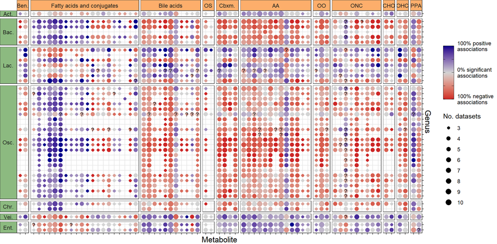

```r
# Plot only taxa and metabolites that are most associated
taxa.to.plot <- lm.results.sum %>%
 group_by(Taxon) %>%
 summarise(Portion.Associated = sum(N.Signif)/sum(N.Datasets), .groups = "drop") %>%
 slice_max(order_by = Portion.Associated, n = 40) %>%
 pull(Taxon)

mtb.to.plot <- lm.results.sum %>%
 group_by(Compound) %>%
 summarise(Portion.Associated = sum(N.Signif)/sum(N.Datasets), .groups = "drop") %>%
 slice_max(order_by = Portion.Associated, n = 70) %>%
 pull(Compound)

tmp <- lm.results.sum %>%
  filter(Taxon %in% taxa.to.plot & Compound %in% mtb.to.plot) %>%
  # Point colors
  mutate(Point.Color =
           round(pmax((100*N.Signif.Pos/N.Datasets),
                      (100*N.Signif.Neg/N.Datasets)), 2)) %>%
  mutate(Point.Color = ifelse(N.Signif.Pos > N.Signif.Neg,
                              Point.Color, -Point.Color)) %>%
  mutate(Mark.Conflict = ifelse(N.Signif.Pos > 0 &
                                  N.Signif.Neg > 0,
                                "?", "")) %>%
  select(Compound, HMDB.Name, HMDB.Class,
         HMDB.Sub.Class, HMDB.Super.Class,
         Taxon, Taxon.Phylum,
         N.Datasets, Point.Color,
         Mark.Conflict) %>%
  # To sort bacterial orders by their phyla we use full ('F') order name
  mutate(Taxon.Order.Full = gsub(";f__.*$", "", Taxon))

# We manually re-group metabolite classes for plotting clarity
# See: View(data.frame(table(hmdb.data %>% filter(Compound %in% mtb.to.plot) %>% select(HMDB.Sub.Class, HMDB.Class, HMDB.Super.Class), useNA = "ifany")) %>% filter(Freq>0))

tmp <- tmp %>%
  mutate(HMDB.Class2 = HMDB.Class) %>%
  mutate(HMDB.Class2 = ifelse(HMDB.Super.Class == "Benzenoids",
                              "Benzenoids", HMDB.Class2)) %>%
  mutate(HMDB.Class2 = ifelse((!is.na(HMDB.Sub.Class)) &
                                HMDB.Sub.Class == "Fatty acids and conjugates",
                              "Fatty acids and conjugates", HMDB.Class2)) %>%
  mutate(HMDB.Class2 = ifelse((!is.na(HMDB.Sub.Class)) &
                                HMDB.Sub.Class == "Bile acids, alcohols and derivatives",
                              "Bile acids, alcohols and derivatives", HMDB.Class2)) %>%
  mutate(HMDB.Class2 = ifelse((!is.na(HMDB.Sub.Class)) &
                                HMDB.Sub.Class %in%
                                c("Cholestane steroids","Stigmastanes and derivatives"),
                              "Other steroids and steroid derivatives", HMDB.Class2)) %>%
  mutate(HMDB.Class2 = ifelse((!is.na(HMDB.Sub.Class)) &
                                HMDB.Sub.Class == "Carboximidic acids",
                              "Carboximidic acids", HMDB.Class2)) %>%
  mutate(HMDB.Class2 = ifelse((!is.na(HMDB.Sub.Class)) &
                                HMDB.Sub.Class == "Amino acids, peptides, and analogues",
                              "Amino acids, peptides, and analogues", HMDB.Class2)) %>%
  mutate(HMDB.Class2 = ifelse((!is.na(HMDB.Sub.Class)) &
                                HMDB.Sub.Class %in% c("Carboxylic acid derivatives",
                                                    "Dicarboxylic acids and derivatives",
                                                    "Alpha hydroxy acids and derivatives",
                                                    "Ureas",
                                                    "Organosulfonic acids and derivatives"),
                              "Other organic acids and derivatives", HMDB.Class2)) %>%
  mutate(HMDB.Class2 = ifelse((!is.na(HMDB.Sub.Class)) &
                                HMDB.Sub.Class == "Carbohydrates and carbohydrate conjugates",
                              "Carbohydrates and carbohydrate conjugates", HMDB.Class2)) %>%
  mutate(HMDB.Class2 = ifelse(HMDB.Super.Class == "Organoheterocyclic compounds",
                              "Organoheterocyclic compounds", HMDB.Class2)) %>%
  # Order according to super classes
  mutate(HMDB.Class2 =
           factor(HMDB.Class2,
                  levels = c("Benzenoids",
                             "Fatty acids and conjugates",
                             "Bile acids, alcohols and derivatives",
                             "Other steroids and steroid derivatives",
                             "Carboximidic acids",
                             "Carboxylic acids and derivatives",
                             "Amino acids, peptides, and analogues",
                             "Other organic acids and derivatives",
                             "Organonitrogen compounds",
                             "Carbohydrates and carbohydrate conjugates",
                             "Organoheterocyclic compounds",
                             "Phenylpropanoic acids"),
                  labels = c("Ben.",
                            "Fatty acids and conjugates",
                            "Bile acids",
                            "OS",
                            "Cbxm.",
                            "COOH",
                            "AA",
                            "OO",
                            "ONC",
                            "CHO",
                            "OHC",
                            "PPA"))) %>%
  mutate(Taxon.Order.Full =
           factor(Taxon.Order.Full,
                  levels = sort(unique(tmp$Taxon.Order.Full)),
                  labels = c("Act.",
                             "Bac.",
                             "Lac.",
                             "Osc.",
                             "Chr.",
                             "Vei.",
                             "Ent.")))

# Inspect re-grouping: View(tmp %>% select(Compound, HMDB.Name, HMDB.Sub.Class, HMDB.Class, HMDB.Super.Class, HMDB.Class2) %>% distinct() %>% rename(Class.for.Plotting = HMDB.Class2) %>% arrange(Class.for.Plotting))

ggplot(tmp, aes(y = Taxon,
                x = Compound,
                color = Point.Color,
                size = N.Datasets,
                label = Mark.Conflict)) +
  geom_point() +
  geom_text(size = 3,
            color = "black",
            hjust = 0.5,
            vjust = 0.5) +
  scale_color_gradient2(low = "firebrick3",
                        high = "blue4",
                        mid = "lightgrey",
                        midpoint = 0,
                        name = "",
                        labels = c("100% negative\nassociations", "",
                                   "0% significant\nassociations", "",
                                   "100% positive\nassociations"),
                        guide = guide_colorbar(frame.colour = "black",
                                               ticks.colour = "black"),
                        limits = c(-100,100),
                        na.value = "white") +
  scale_size_continuous(breaks = 3:10, range = c(2,4), name = "No. datasets") +
  scale_y_discrete(position = "right") +
  xlab("Metabolite") +
  ylab("Genus") +
  theme_bw() +
  facet_grid(cols = vars(HMDB.Class2),
             rows = vars(Taxon.Order.Full),
             scales = "free", space = "free", switch = "y") +
  theme(panel.spacing = unit(0.2, "lines")) +
  theme(axis.text = element_blank()) +
  theme(axis.title = element_text(size = 13)) +
  theme(strip.background.y = element_rect(fill = '#8CBA80')) +
  theme(strip.background.x = element_rect(fill = '#FDAE6B')) +
  theme(strip.text = element_text(size = 9)) +
  theme(strip.text.y.left = element_text(angle = 0)) +
  theme(panel.grid.major = element_line(colour = "gray90")) +
  theme(legend.text = element_text(size = 9)) +
  theme(plot.margin = margin(r = 0))
```

## Identify consistent associations

### Fit a random-effects model per pair

```r
if (file.exists(file.rem.results)) {
  rems <- read_delim(file.rem.results,
                     delim = "\t",
                     show_col_types = FALSE,
                     escape_double = FALSE,
                     trim_ws = TRUE)
} else {
  rem.pairs <- lm.results %>%
    select(Pair, Compound, Taxon,
           Dataset, Dataset.N, LM.Taxon.r.sp) %>%
    nest_by(Pair, Compound, Taxon, .key = "REM.Data")

  # Iterate over pairs to fit an REM per pair
  rems <- lapply(1:nrow(rem.pairs), function(i) {
    if (i%%100 == 0) cat('.')
    if (i%%1000 == 0) cat('|')

    # Fetch relevant data
    data.for.rem <- rem.pairs[i,] %>% tidyr::unnest(REM.Data)

    # Fit a REM
    rem <- metacor(cor = data.for.rem$LM.Taxon.r.sp,
                   n = data.for.rem$Dataset.N,
                   studlab = data.for.rem$Dataset,
                   hakn = FALSE,
                   fixed = FALSE,
                   random = TRUE)

    rem.w.hakn <- metacor(cor = data.for.rem$LM.Taxon.r.sp,
                         n = data.for.rem$Dataset.N,
                         studlab = data.for.rem$Dataset,
                         hakn = TRUE,
                         fixed = FALSE,
                         random = TRUE)

    # Report main statistics per REM
    return(data.frame(Compound = rem.pairs[i,"Compound"],
                      Taxon = rem.pairs[i,"Taxon"],
                      Pair = rem.pairs[i,"Pair"],
                      N.Datasets = rem$k,
                      REM.TE = rem$TE.random,
                      REM.TE.Upper = rem$upper.random,
                      REM.TE.Lower = rem$lower.random,
                      REM.P = rem$pval.random,
                      REM.P.HAKN = rem.w.hakn$pval.random,
                      REM.I2 = rem$I2,
                      REM.I2.Upper = rem$upper.I2,
                      REM.I2.Lower = rem$lower.I2))
  })

  # Merge into one big table
  rems <- bind_rows(rems)

  # Correct for multiple testing
  rems$REM.FDR <- p.adjust(rems$REM.P, method = "fdr")
  rems$REM.FDR.HAKN <- p.adjust(rems$REM.P.HAKN, method = "fdr")

  # Save to file
  write_delim(rems, file = file.rem.results, delim = "\t")
}
```

Print statistics:

```r
paste0("A total of ", nrow(rems), " random-effects models were fitted")
n.rem.signif <- rems %>% filter(REM.FDR <= 0.05) %>% nrow()
paste0(n.rem.signif, " (", round(100*n.rem.signif/nrow(rems),2), "%) of which had an FDR <= 0.05")
n.rem.signif <- rems %>% filter(REM.FDR <= 0.1) %>% nrow()
paste0(n.rem.signif, " (", round(100*n.rem.signif/nrow(rems),2), "%) of which had an FDR <= 0.1")
n.rem.signif <- rems %>% filter(REM.FDR.HAKN <= 0.05) %>% nrow()
paste0(n.rem.signif, " (", round(100*n.rem.signif/nrow(rems),2), "%) of which had an FDR <= 0.05 when using HAKN correction")
n.rem.signif <- rems %>% filter(REM.FDR.HAKN <= 0.1) %>% nrow()
paste0(n.rem.signif, " (", round(100*n.rem.signif/nrow(rems),2), "%) of which had an FDR <= 0.1 when using HAKN correction")
```

```
## [1] "A total of 29708 random-effects models were fitted"
## [1] "5423 (18.25%) of which had an FDR <= 0.05"
## [1] "6933 (23.34%) of which had an FDR <= 0.1"
## [1] "307 (1.03%) of which had an FDR <= 0.05 when using HAKN correction"
## [1] "1101 (3.71%) of which had an FDR <= 0.1 when using HAKN correction"
```

Define a criteria for considering a genus-metabolite as “consistently positively/negatively associated”:

```r
lm.results.sum <- lm.results.sum %>%
  left_join(rems, by = c("Pair","Taxon","Compound","N.Datasets")) %>%
  mutate(Consis.Assoc.Pos = REM.FDR.HAKN <= 0.1 & REM.TE > 0) %>%
  mutate(Consis.Assoc.Neg = REM.FDR.HAKN <= 0.1 & REM.TE < 0) %>%
  mutate(Consis.Assoc = Consis.Assoc.Pos | Consis.Assoc.Neg)
```

Print statistics providing an overview of results:

```r
n.total <- lm.results.sum %>% nrow()
sprintf("%i genus-metabolite pairs were analyzed", n.total)
n <- lm.results.sum %>% filter(Consis.Assoc) %>% nrow()
sprintf("%i (%.2f%%) of which were consistently associated in the analyzed datasets", n, 100*n/n.total)
n <- lm.results.sum %>% filter(Consis.Assoc.Pos) %>% nrow()
sprintf("%i (%.2f%%) of which were consistently positively associated in the analyzed datasets", n, 100*n/n.total)
n <- lm.results.sum %>% filter(Consis.Assoc.Neg) %>% nrow()
sprintf("%i (%.2f%%) of which were consistently negatively associated in the analyzed datasets", n, 100*n/n.total)
n <- lm.results.sum %>% filter(N.Signif.Pos >= 1 & N.Signif.Neg >= 1) %>% nrow()
sprintf("%i (%.2f%%) had conflicting significant associations across different datasets (>=1 positive associations and >=1 negative ones)",
                 n, 100*n/n.total)
sprintf("")

# Metabolite-level statistics
n.total <- lm.results.sum %>% pull(Compound) %>% n_distinct()
sprintf("%i unique metabolites were analyzed", n.total)
mtb_assoc_counts <- lm.results.sum %>%
  group_by(Compound) %>%
  summarise(Count.Consis.Assoc = sum(Consis.Assoc))
n <- sum(mtb_assoc_counts$Count.Consis.Assoc > 0)
sprintf("%i (%.2f%%) of which were consistently associated with 1 or more genera", n, 100*n/n.total)
n <- sum(mtb_assoc_counts$Count.Consis.Assoc >= 10)
sprintf("%i (%.2f%%) of which were consistently associated with 10 or more genera", n, 100*n/n.total)
n <- sum(mtb_assoc_counts$Count.Consis.Assoc >= 20)
sprintf("%i (%.2f%%) of which were consistently associated with 20 or more genera", n, 100*n/n.total)
sprintf("")

# Genus-level statistics
n.total <- lm.results.sum %>% pull(Taxon) %>% n_distinct()
sprintf("%i unique genera were analyzed", n.total)
tax_assoc_counts <- lm.results.sum %>%
  group_by(Taxon) %>%
  summarise(Count.Consis.Assoc = sum(Consis.Assoc))
n <- sum(tax_assoc_counts$Count.Consis.Assoc > 0)
sprintf("%i (%.2f%%) of which were consistently associated with 1 or more metabolites", n, 100*n/n.total)
n <- sum(tax_assoc_counts$Count.Consis.Assoc >= 10)
sprintf("%i (%.2f%%) of which were consistently associated with 10 or more metabolites", n, 100*n/n.total)
n <- sum(tax_assoc_counts$Count.Consis.Assoc >= 20)
sprintf("%i (%.2f%%) of which were consistently associated with 20 or more metabolites", n, 100*n/n.total)
```

```
## [1] "29708 genus-metabolite pairs were analyzed"
## [1] "1101 (3.71%) of which were consistently associated in the analyzed datasets"
## [1] "365 (1.23%) of which were consistently positively associated in the analyzed datasets"
## [1] "736 (2.48%) of which were consistently negatively associated in the analyzed datasets"
## [1] "465 (1.57%) had conflicting significant associations across different datasets (>=1 positive associations and >=1 negative ones)"
## [1] ""
## [1] "314 unique metabolites were analyzed"
## [1] "195 (62.10%) of which were consistently associated with 1 or more genera"
## [1] "39 (12.42%) of which were consistently associated with 10 or more genera"
## [1] "9 (2.87%) of which were consistently associated with 20 or more genera"
## [1] ""
## [1] "109 unique genera were analyzed"
## [1] "104 (95.41%) of which were consistently associated with 1 or more metabolites"
## [1] "39 (35.78%) of which were consistently associated with 10 or more metabolites"
## [1] "13 (11.93%) of which were consistently associated with 20 or more metabolites"
```

### Explore consistent associations

#### A bipartite network of consistent association

Export to CytoScape to visualize consistent network of genus-metabolite links:

```r
cytoscape.network <- lm.results.sum %>%
  filter(Consis.Assoc) %>%
  select(Taxon, Compound, N.Datasets, REM.TE, REM.P.HAKN) %>%
  mutate(interaction = ifelse(REM.TE > 0, "pos_assoc", "neg_assoc")) %>%
  rename(source = Taxon) %>%
  rename(target = Compound) %>%
  relocate(source, interaction, target) %>%
  rename(n_datasets = N.Datasets)

cytoscape.nodes.genera <- lm.results.sum %>%
  filter(Consis.Assoc) %>%
  select(Taxon, Taxon.Phylum, Taxon.Class, Taxon.Order, Taxon.Family, Taxon.Genus) %>%
  distinct() %>%
  left_join(genera.dataset.stats %>%
              select(Taxon,
                     Averaged.Taxon.Mean.Abundance,
                     Averaged.Taxon.Perc.of.Non.Zeros) %>%
              distinct(),
            by = "Taxon") %>%
  rename(node = Taxon) %>%
  mutate(node_type = "Genus") %>%
  rename(taxon_phylum = Taxon.Phylum) %>%
  rename(taxon_class = Taxon.Class) %>%
  rename(taxon_order = Taxon.Order) %>%
  rename(taxon_family = Taxon.Family) %>%
  rename(taxon_genus = Taxon.Genus) %>%
  rename(averaged_taxon_mean_abundance = Averaged.Taxon.Mean.Abundance) %>%
  rename(averaged_taxon_perc_of_non_zeros = Averaged.Taxon.Perc.of.Non.Zeros)

cytoscape.nodes.metab <- lm.results.sum %>%
  filter(Consis.Assoc) %>%
  select(Compound, HMDB.Name,
         HMDB.Sub.Class,
         HMDB.Class,
         HMDB.Super.Class,
         HMDB.Source.Food,
         HMDB.Source.Microbial) %>%
  distinct() %>%
  rename(node = Compound) %>%
  mutate(node_type = "Metabolite") %>%
  rename(HMDB_name = HMDB.Name) %>%
  rename(HMDB_sub_class = HMDB.Sub.Class) %>%
  rename(HMDB_class = HMDB.Class) %>%
  rename(HMDB_super_Class = HMDB.Super.Class) %>%
  rename(HMDB_source_food = HMDB.Source.Food) %>%
  rename(HMDB_source_microbial = HMDB.Source.Microbial)

cytoscape.nodes <-
  bind_rows(cytoscape.nodes.genera, cytoscape.nodes.metab) %>%
  mutate(taxon_phylum_or_hmdb_class =
           coalesce(taxon_phylum, HMDB_class)) %>%
  mutate(node_size_factor =
           ifelse(is.na(averaged_taxon_mean_abundance),
                        0.002,
                        averaged_taxon_mean_abundance))

write_delim(cytoscape.network, file = file.cytoscape.network, delim = "\t")
write_delim(cytoscape.nodes, file = file.cytoscape.nodes, delim = "\t", na = "")
```

#### Are abundant genera also associated with more metabolites?

We use a linear model to assess whether higher genus abundances are associated with a higher probability to come out significant in an association.

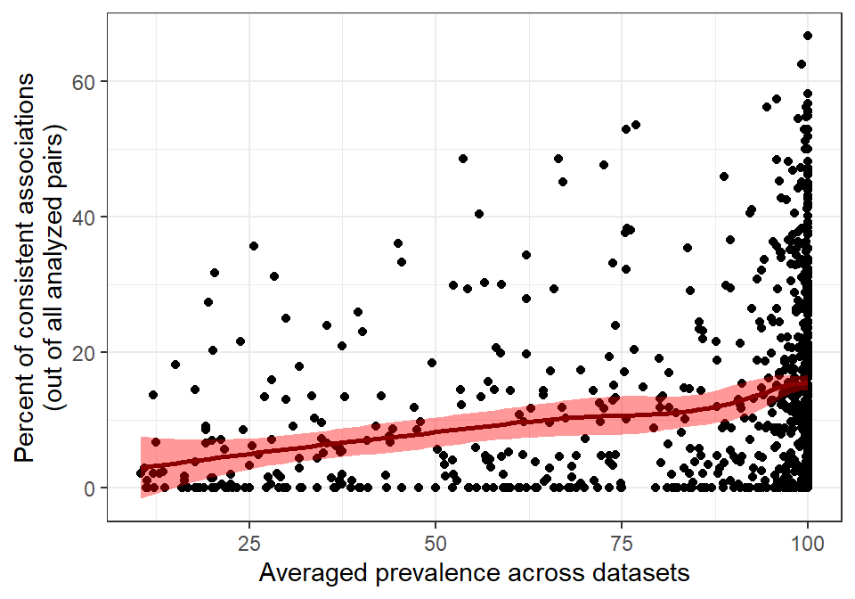

```r
tmp <-
  genera.dataset.stats %>%
  select(Taxon,
         Dataset,
         Taxon.Mean.Abundance,
         Taxon.Perc.of.Non.Zeros) %>%
  distinct() %>%
  inner_join(lm.results %>%
              group_by(Taxon, Dataset) %>%
              summarise(N.Pairs = n(),
                        N.Associations = sum(LM.Taxon.FDR < 0.05),
                        .groups = "drop"),
            by = c("Taxon", "Dataset")) %>%
  mutate(N.Associations = tidyr::replace_na(N.Associations, 0)) %>%
  mutate(Perc.Consis.Assoc = 100 * N.Associations / N.Pairs)

ggplot(tmp, aes(x = Taxon.Perc.of.Non.Zeros,
                y = Perc.Consis.Assoc)) +
  geom_point() +
  stat_smooth(method = loess, color = "darkred", fill = "red") +
  ylab("Percent of consistent associations\n(out of all analyzed pairs)") +
  xlab("Averaged prevalence across datasets") +
  theme_bw()
```

```r
summary(lm(Perc.Consis.Assoc ~ Taxon.Mean.Abundance + Taxon.Perc.of.Non.Zeros + N.Pairs, data = tmp))
```

```
##
## Call:
## lm(formula = Perc.Consis.Assoc ~ Taxon.Mean.Abundance + Taxon.Perc.of.Non.Zeros +
##     N.Pairs, data = tmp)
##
## Residuals:
##     Min      1Q  Median      3Q     Max
## -16.825 -10.837  -2.979   6.923  53.237
##
## Coefficients:
##                           Estimate Std. Error t value             Pr(>|t|)
## (Intercept)              -1.031091   1.588277  -0.649              0.51636
## Taxon.Mean.Abundance    -26.074084  17.620566  -1.480              0.13925
## Taxon.Perc.of.Non.Zeros   0.144443   0.016838   8.578 < 0.0000000000000002 ***
## N.Pairs                   0.015384   0.005137   2.995              0.00281 **
## ---
## Signif. codes:  0 '***' 0.001 '**' 0.01 '*' 0.05 '.' 0.1 ' ' 1
##
## Residual standard error: 13.64 on 1020 degrees of freedom
## Multiple R-squared:  0.07569,    Adjusted R-squared:  0.07297
## F-statistic: 27.84 on 3 and 1020 DF,  p-value: < 0.00000000000000022
```

Evidently, prevalent taxa are more likely to come out significantly associated to metabolites. We hypothesize that this is both due to a statistical reason - more zeros mean lower variance in the data, and a biological reason - very rare genera might have limited ability to alter the surrounding metabolome, making it harder to detect associations.

#### Metabolite class enrichment analysis

Are some metabolite classes (super classes) enriched in microbe-associated metabolites?

```r
mtb.enrich.analysis <- lm.results.sum %>%
  select(Compound, HMDB.Super.Class, Consis.Assoc) %>%
  group_by(Compound, HMDB.Super.Class) %>%
  summarise(N.Genera = n(), Any.Associated = any(Consis.Assoc), .groups = "drop")

classes.to.analyze <- mtb.enrich.analysis %>%
  group_by(HMDB.Super.Class) %>%
  filter(n_distinct(Compound) >= 5) %>%
  pull(HMDB.Super.Class) %>%
  unique()

# g = "Steroids and steroid derivatives"
fishers <- lapply(classes.to.analyze, function(g) {
  # Build 2X2 confusion matrix for fisher.test
  N.assoc.in.group  <- mtb.enrich.analysis %>%
    filter(HMDB.Super.Class == g) %>%
    filter(Any.Associated) %>% nrow()
  N.nassoc.in.group  <- mtb.enrich.analysis %>%
    filter(HMDB.Super.Class == g) %>%
    filter(!Any.Associated) %>% nrow()
  N.assoc.nin.group  <- mtb.enrich.analysis %>%
    filter(HMDB.Super.Class != g) %>%
    filter(Any.Associated) %>% nrow()
  N.nassoc.nin.group <- mtb.enrich.analysis %>%
    filter(HMDB.Super.Class != g) %>%
    filter(!Any.Associated) %>% nrow()

  fmat <- matrix(c(N.assoc.in.group, N.nassoc.in.group,
                   N.assoc.nin.group, N.nassoc.nin.group),
                 nrow = 2, ncol = 2, byrow = F)
  colnames(fmat) <- c("associated", "non.associated")
  rownames(fmat) <- c("in.group", "not.in.group")

  # Calculate Fisher
  fish <- fisher.test(fmat, alternative = "greater")

  data.frame(Class = g,
             N.assoc.in.group = N.assoc.in.group,
             N.nassoc.in.group = N.nassoc.in.group,
             N.assoc.nin.group = N.assoc.nin.group,
             N.nassoc.nin.group = N.nassoc.nin.group,
             OR = unname(fish$estimate),
             OR.95.CI.lower = fish$conf.int[1],
             OR.95.CI.upper = fish$conf.int[2],
             P = fish$p.value)
})
fishers <- bind_rows(fishers)
fishers$FDR <- p.adjust(fishers$P, method = "fdr")

# Print results
fishers %>%
  arrange(P) %>%
  kbl() %>%
  kable_styling(font_size = 8)
sprintf("Found %i enriched metabolite classes", sum(fishers$FDR<0.1))
```

| Class | N.assoc.in.group | N.nassoc.in.group | N.assoc.nin.group | N.nassoc.nin.group | OR | OR.95.CI.lower | OR.95.CI.upper | P | FDR |
| --- | --- | --- | --- | --- | --- | --- | --- | --- | --- |
| Organic nitrogen compounds | 21 | 4 | 173 | 115 | 3.4783090 | 1.3074324 | Inf | 0.0126221 | 0.0883550 |
| Organic acids and derivatives | 68 | 39 | 126 | 80 | 1.1066802 | 0.7182156 | Inf | 0.3871302 | 0.9184193 |
| Lipids and lipid-like molecules | 41 | 25 | 153 | 94 | 1.0075577 | 0.6084211 | Inf | 0.5488385 | 0.9184193 |
| Benzenoids | 13 | 8 | 181 | 111 | 0.9965577 | 0.4252794 | Inf | 0.6005481 | 0.9184193 |
| Organic oxygen compounds | 12 | 9 | 182 | 110 | 0.8064383 | 0.3468783 | Inf | 0.7619571 | 0.9184193 |
| Organoheterocyclic compounds | 26 | 19 | 168 | 100 | 0.8150889 | 0.4539832 | Inf | 0.7872166 | 0.9184193 |
| Nucleosides, nucleotides, and analogues | 7 | 12 | 187 | 107 | 0.3350130 | 0.1288378 | Inf | 0.9943627 | 0.9943627 |

```
## [1] "Found 1 enriched metabolite classes"
```

Are some metabolite classes enriched in **specific-phylum**-associated metabolites?

```r
mtb.enrich.analysis2 <- lm.results.sum %>%
  select(Compound, HMDB.Super.Class, Taxon.Phylum, Consis.Assoc) %>%
  mutate(Taxon.Phylum = ifelse(is.na(Taxon.Phylum), "Unclassified", Taxon.Phylum)) %>%
  group_by(Compound, HMDB.Super.Class, Taxon.Phylum) %>%
  summarise(N.Genera = n(), Any.Associated = any(Consis.Assoc), .groups = "drop") %>%
  tidyr::pivot_wider(id_cols = c(Compound, HMDB.Super.Class),
                     names_from = Taxon.Phylum,
                     values_from = Any.Associated,
                     values_fill = FALSE)

phyla.to.analyze <- names(mtb.enrich.analysis2)[-1:-2]

# Test: g = "Organic acids and derivatives"
fishers <- lapply(classes.to.analyze, function(g) {
  # Test: p = "Unclassified"
  fishers.phylum <- lapply(phyla.to.analyze, function(p) {
    # Build 2X2 confusion matrix for fisher.test
    N.assoc.in.group  <- mtb.enrich.analysis2 %>%
      filter(HMDB.Super.Class == g) %>%
      filter(!!as.symbol(p)) %>% nrow()
    N.nassoc.in.group  <- mtb.enrich.analysis2 %>%
      filter(HMDB.Super.Class == g) %>%
      filter(!(!!as.symbol(p))) %>% nrow()
    N.assoc.nin.group  <- mtb.enrich.analysis2 %>%
      filter(HMDB.Super.Class != g) %>%
      filter(!!as.symbol(p)) %>% nrow()
    N.nassoc.nin.group <- mtb.enrich.analysis2 %>%
      filter(HMDB.Super.Class != g) %>%
      filter(!(!!as.symbol(p))) %>% nrow()

    fmat <- matrix(c(N.assoc.in.group, N.nassoc.in.group,
                     N.assoc.nin.group, N.nassoc.nin.group),
                   nrow = 2, ncol = 2, byrow = F)
    colnames(fmat) <- c("associated", "non.associated")
    rownames(fmat) <- c("in.group", "not.in.group")

    # Calculate Fisher
    fish <- fisher.test(fmat, alternative = "greater")

    # Return
    data.frame(Class = g,
               Phylum = p,
               N.assoc.in.group = N.assoc.in.group,
               N.nassoc.in.group = N.nassoc.in.group,
               N.assoc.nin.group = N.assoc.nin.group,
               N.nassoc.nin.group = N.nassoc.nin.group,
               OR = unname(fish$estimate),
               OR.95.CI.lower = fish$conf.int[1],
               OR.95.CI.upper = fish$conf.int[2],
               P = fish$p.value)
  })

  # Return
  bind_rows(fishers.phylum)
})

# Organize results and apply FDR correction
fishers <- bind_rows(fishers)
fishers$FDR <- p.adjust(fishers$P, method = "fdr")

# Print results
fishers %>%
  select(Class, Phylum, OR, OR.95.CI.lower, OR.95.CI.upper, P, FDR) %>%
  arrange(P) %>%
  kbl() %>%
  kable_styling(font_size = 8)
sprintf("Found %i metabolite class enriched with specific phylum-associated metabolites", sum(fishers$FDR<0.1))
```

| Class | Phylum | OR | OR.95.CI.lower | OR.95.CI.upper | P | FDR |
| --- | --- | --- | --- | --- | --- | --- |
| Organic acids and derivatives | p__Bacteroidota | 3.2156123 | 2.0193791 | Inf | 0.0000072 | 0.0005010 |
| Organic acids and derivatives | p__Firmicutes | 2.2940653 | 1.2902558 | Inf | 0.0074296 | 0.2600351 |
| Organic nitrogen compounds | p__Firmicutes_A | 2.4940803 | 1.0932103 | Inf | 0.0316406 | 0.5832013 |
| Organic nitrogen compounds | p__Desulfobacterota | 12.1996741 | 1.2690224 | Inf | 0.0333258 | 0.5832013 |
| Organic nitrogen compounds | p__Firmicutes | 2.4026136 | 0.9456548 | Inf | 0.0617048 | 0.8504428 |
| Lipids and lipid-like molecules | p__Firmicutes_C | 1.8398686 | 0.9284491 | Inf | 0.0728951 | 0.8504428 |
| Nucleosides, nucleotides, and analogues | p__Actinobacteriota | 4.1717427 | 0.5950248 | Inf | 0.1174136 | 1.0000000 |
| Organic acids and derivatives | p__Proteobacteria | 1.6325104 | 0.8456535 | Inf | 0.1174484 | 1.0000000 |
| Organic acids and derivatives | p__Verrucomicrobiota | 1.9952977 | 0.7488851 | Inf | 0.1366694 | 1.0000000 |
| Lipids and lipid-like molecules | p__Proteobacteria | 1.5156462 | 0.7076177 | Inf | 0.2005911 | 1.0000000 |
| Organic acids and derivatives | p__Firmicutes_A | 1.2511400 | 0.8219035 | Inf | 0.2062359 | 1.0000000 |
| Organic nitrogen compounds | p__Bacteroidota | 1.5666360 | 0.6799044 | Inf | 0.2082101 | 1.0000000 |
| Lipids and lipid-like molecules | p__Fusobacteriota | Inf | 0.1969687 | Inf | 0.2108626 | 1.0000000 |
| Lipids and lipid-like molecules | Unclassified | Inf | 0.1969687 | Inf | 0.2108626 | 1.0000000 |
| Organic acids and derivatives | p__Firmicutes_C | 1.3660861 | 0.7337279 | Inf | 0.2252802 | 1.0000000 |
| Benzenoids | p__Desulfobacterota | 4.7709130 | 0.1777825 | Inf | 0.2436015 | 1.0000000 |
| Organic oxygen compounds | p__Verrucomicrobiota | 2.0836995 | 0.3170341 | Inf | 0.2920600 | 1.0000000 |
| Lipids and lipid-like molecules | p__Firmicutes_A | 1.2048182 | 0.7354267 | Inf | 0.2976949 | 1.0000000 |
| Organic nitrogen compounds | p__Verrucomicrobiota | 1.6983367 | 0.2610703 | Inf | 0.3712884 | 1.0000000 |
| Lipids and lipid-like molecules | p__Firmicutes | 1.1715728 | 0.5755686 | Inf | 0.4000200 | 1.0000000 |
| Organoheterocyclic compounds | p__Actinobacteriota | 1.5093439 | 0.2236025 | Inf | 0.4343716 | 1.0000000 |
| Organic nitrogen compounds | p__Firmicutes_C | 1.2521651 | 0.3753085 | Inf | 0.4392966 | 1.0000000 |
| Organic acids and derivatives | p__Actinobacteriota | 1.2933564 | 0.3354094 | Inf | 0.4643294 | 1.0000000 |
| Benzenoids | p__Actinobacteriota | 1.5694794 | 0.0693824 | Inf | 0.5059188 | 1.0000000 |
| Organic oxygen compounds | p__Actinobacteriota | 1.5694794 | 0.0693824 | Inf | 0.5059188 | 1.0000000 |
| Benzenoids | p__Firmicutes_A | 0.9993485 | 0.4306463 | Inf | 0.5909012 | 1.0000000 |
| Organoheterocyclic compounds | p__Proteobacteria | 0.9557634 | 0.3356902 | Inf | 0.6169176 | 1.0000000 |
| Lipids and lipid-like molecules | p__Verrucomicrobiota | 0.8575499 | 0.2028026 | Inf | 0.6934685 | 1.0000000 |
| Organic oxygen compounds | p__Bacteroidota | 0.8286153 | 0.2822232 | Inf | 0.7214430 | 1.0000000 |
| Benzenoids | p__Proteobacteria | 0.7992939 | 0.1275887 | Inf | 0.7235650 | 1.0000000 |
| Benzenoids | p__Firmicutes_C | 0.6639231 | 0.1065232 | Inf | 0.8036288 | 1.0000000 |
| Organic nitrogen compounds | p__Proteobacteria | 0.6503959 | 0.1049443 | Inf | 0.8117270 | 1.0000000 |
| Organic acids and derivatives | p__Desulfobacterota | 0.6392090 | 0.0244686 | Inf | 0.8142511 | 1.0000000 |
| Organic oxygen compounds | p__Firmicutes_A | 0.6637813 | 0.2790474 | Inf | 0.8712647 | 1.0000000 |
| Organoheterocyclic compounds | p__Firmicutes_C | 0.5913842 | 0.1837862 | Inf | 0.8896905 | 1.0000000 |
| Organoheterocyclic compounds | p__Bacteroidota | 0.6324358 | 0.2949308 | Inf | 0.9142903 | 1.0000000 |
| Organoheterocyclic compounds | p__Verrucomicrobiota | 0.3841850 | 0.0180921 | Inf | 0.9219367 | 1.0000000 |
| Organoheterocyclic compounds | p__Firmicutes | 0.5113901 | 0.1596918 | Inf | 0.9368835 | 1.0000000 |
| Nucleosides, nucleotides, and analogues | p__Firmicutes_C | 0.3436378 | 0.0163232 | Inf | 0.9407536 | 1.0000000 |
| Nucleosides, nucleotides, and analogues | p__Firmicutes_A | 0.5101170 | 0.1965929 | Inf | 0.9497598 | 1.0000000 |
| Lipids and lipid-like molecules | p__Bacteroidota | 0.5970926 | 0.3163678 | Inf | 0.9573983 | 1.0000000 |
| Benzenoids | p__Bacteroidota | 0.2659021 | 0.0432851 | Inf | 0.9905150 | 1.0000000 |
| Organoheterocyclic compounds | p__Firmicutes_A | 0.4484909 | 0.2422887 | Inf | 0.9955525 | 1.0000000 |
| Organic acids and derivatives | p__Fusobacteriota | 0.0000000 | 0.0000000 | Inf | 1.0000000 | 1.0000000 |
| Organic acids and derivatives | Unclassified | 0.0000000 | 0.0000000 | Inf | 1.0000000 | 1.0000000 |
| Nucleosides, nucleotides, and analogues | p__Bacteroidota | 0.0000000 | 0.0000000 | Inf | 1.0000000 | 1.0000000 |
| Nucleosides, nucleotides, and analogues | p__Desulfobacterota | 0.0000000 | 0.0000000 | Inf | 1.0000000 | 1.0000000 |
| Nucleosides, nucleotides, and analogues | p__Firmicutes | 0.0000000 | 0.0000000 | Inf | 1.0000000 | 1.0000000 |
| Nucleosides, nucleotides, and analogues | p__Fusobacteriota | 0.0000000 | 0.0000000 | Inf | 1.0000000 | 1.0000000 |
| Nucleosides, nucleotides, and analogues | p__Proteobacteria | 0.0000000 | 0.0000000 | Inf | 1.0000000 | 1.0000000 |
| Nucleosides, nucleotides, and analogues | p__Verrucomicrobiota | 0.0000000 | 0.0000000 | Inf | 1.0000000 | 1.0000000 |
| Nucleosides, nucleotides, and analogues | Unclassified | 0.0000000 | 0.0000000 | Inf | 1.0000000 | 1.0000000 |
| Organoheterocyclic compounds | p__Desulfobacterota | 0.0000000 | 0.0000000 | Inf | 1.0000000 | 1.0000000 |
| Organoheterocyclic compounds | p__Fusobacteriota | 0.0000000 | 0.0000000 | Inf | 1.0000000 | 1.0000000 |
| Organoheterocyclic compounds | Unclassified | 0.0000000 | 0.0000000 | Inf | 1.0000000 | 1.0000000 |
| Benzenoids | p__Firmicutes | 0.0000000 | 0.0000000 | Inf | 1.0000000 | 1.0000000 |
| Benzenoids | p__Fusobacteriota | 0.0000000 | 0.0000000 | Inf | 1.0000000 | 1.0000000 |
| Benzenoids | p__Verrucomicrobiota | 0.0000000 | 0.0000000 | Inf | 1.0000000 | 1.0000000 |
| Benzenoids | Unclassified | 0.0000000 | 0.0000000 | Inf | 1.0000000 | 1.0000000 |
| Lipids and lipid-like molecules | p__Actinobacteriota | 0.0000000 | 0.0000000 | Inf | 1.0000000 | 1.0000000 |
| Lipids and lipid-like molecules | p__Desulfobacterota | 0.0000000 | 0.0000000 | Inf | 1.0000000 | 1.0000000 |
| Organic nitrogen compounds | p__Actinobacteriota | 0.0000000 | 0.0000000 | Inf | 1.0000000 | 1.0000000 |
| Organic nitrogen compounds | p__Fusobacteriota | 0.0000000 | 0.0000000 | Inf | 1.0000000 | 1.0000000 |
| Organic nitrogen compounds | Unclassified | 0.0000000 | 0.0000000 | Inf | 1.0000000 | 1.0000000 |
| Organic oxygen compounds | p__Desulfobacterota | 0.0000000 | 0.0000000 | Inf | 1.0000000 | 1.0000000 |
| Organic oxygen compounds | p__Firmicutes | 0.0000000 | 0.0000000 | Inf | 1.0000000 | 1.0000000 |
| Organic oxygen compounds | p__Firmicutes_C | 0.0000000 | 0.0000000 | Inf | 1.0000000 | 1.0000000 |
| Organic oxygen compounds | p__Fusobacteriota | 0.0000000 | 0.0000000 | Inf | 1.0000000 | 1.0000000 |
| Organic oxygen compounds | p__Proteobacteria | 0.0000000 | 0.0000000 | Inf | 1.0000000 | 1.0000000 |
| Organic oxygen compounds | Unclassified | 0.0000000 | 0.0000000 | Inf | 1.0000000 | 1.0000000 |

```
## [1] "Found 1 metabolite class enriched with specific phylum-associated metabolites"
```